# COD_week13_2_MGK_BTE3207

Minsik Kim

2023-11-24

# Agenda

This lecture will practice running

1. Plackett-Burman Design (PBD)

and

2. Response surface method (RSM)

# Before begin..

Let’s install packages.

```r
install.packages("daewr")
library(daewr)
```

`PBDes` function creates the experimental design of the PBD. randomize = T will generate a matrix with mixed orders.

```r
daewr::PBDes(nfactors = 11, nruns = 12)
```

```
##     A  B  C  D  E  F  G  H  J  K  L
## 1   1  1 -1  1  1  1 -1 -1 -1  1 -1
## 2  -1  1  1 -1  1  1  1 -1 -1 -1  1
## 3   1 -1  1  1 -1  1  1  1 -1 -1 -1
## 4  -1  1 -1  1  1 -1  1  1  1 -1 -1
## 5  -1 -1  1 -1  1  1 -1  1  1  1 -1
## 6  -1 -1 -1  1 -1  1  1 -1  1  1  1
## 7   1 -1 -1 -1  1 -1  1  1 -1  1  1
## 8   1  1 -1 -1 -1  1 -1  1  1 -1  1
## 9   1  1  1 -1 -1 -1  1 -1  1  1 -1
## 10 -1  1  1  1 -1 -1 -1  1 -1  1  1
## 11  1 -1  1  1  1 -1 -1 -1  1 -1  1
## 12 -1 -1 -1 -1 -1 -1 -1 -1 -1 -1 -1
```

After setting your `higher level` and `lower level` based on your intuition, you can run a experiment with 12 experimental groups, and get the result out of the data.

analyiss of PBD outcome

You can run a miultiple linear regression that is containing all the data!

```r
library(tidyverse)
read.csv("/Volumes/MacMini Drive/Dropbox (Personal)/Git/BTE3207_Advanced_Biostatistics(Macmini)_git/BTE3207_Advanced_Biostatistics/PBD_example_data.csv") %>%
        names
```

```
##  [1] "X"        "Glucose"  "YE"       "KH2PO4"   "K2HPO4"   "MgSO4"
##  [7] "CaCl2"    "FeSO4"    "Fructose" "NH4Cl"    "TM"       "Vitamin"
## [13] "Biomass"
```

```r
 lm(Biomass ~ Glucose + YE + KH2PO4 + K2HPO4 + MgSO4 + CaCl2 + FeSO4 + Fructose + NH4Cl + TM + Vitamin,
    data = read.csv("/Volumes/MacMini Drive/Dropbox (Personal)/Git/BTE3207_Advanced_Biostatistics(Macmini)_git/BTE3207_Advanced_Biostatistics/PBD_example_data.csv")) %>% summary
```

```
##
## Call:
## lm(formula = Biomass ~ Glucose + YE + KH2PO4 + K2HPO4 + MgSO4 +
##     CaCl2 + FeSO4 + Fructose + NH4Cl + TM + Vitamin, data = read.csv("/Volumes/MacMini Drive/Dropbox (Personal)/Git/BTE3207_Advanced_Biostatistics(Macmini)_git/BTE3207_Advanced_Biostatistics/PBD_example_data.csv"))
##
## Residuals:
##    Min     1Q Median     3Q    Max
##  -0.04  -0.02   0.00   0.02   0.04
##
## Coefficients:
##              Estimate Std. Error t value Pr(>|t|)
## (Intercept)  2.437500   0.007022 347.134  < 2e-16 ***
## Glucose     -0.012500   0.007022  -1.780 0.100360
## YE           0.845833   0.007022 120.458  < 2e-16 ***
## KH2PO4       0.037500   0.007022   5.341 0.000176 ***
## K2HPO4       0.572500   0.007022  81.532  < 2e-16 ***
## MgSO4        0.032500   0.007022   4.628 0.000582 ***
## CaCl2       -0.054167   0.007022  -7.714 5.45e-06 ***
## FeSO4        0.055833   0.007022   7.951 4.00e-06 ***
## Fructose     0.080833   0.007022  11.512 7.67e-08 ***
## NH4Cl       -0.017500   0.007022  -2.492 0.028315 *
## TM           0.015833   0.007022   2.255 0.043611 *
## Vitamin     -0.019167   0.007022  -2.730 0.018280 *
## ---
## Signif. codes:  0 '***' 0.001 '**' 0.01 '*' 0.05 '.' 0.1 ' ' 1
##
## Residual standard error: 0.0344 on 12 degrees of freedom
## Multiple R-squared:  0.9994, Adjusted R-squared:  0.9989
## F-statistic:  1953 on 11 and 12 DF,  p-value: < 2.2e-16
```

This is your Plackett-Burman result.

## RSM

```r
install.packages("rsm")
library(rsm)
```

using `ccd` function, you can generate a experimental design that can be used for RSM experiment and analysis

```r
ccd (3)
```

```
##    run.order std.order  x1.as.is  x2.as.is  x3.as.is Block
## 1          1        12  0.000000  0.000000  0.000000     1
## 2          2        10  0.000000  0.000000  0.000000     1
## 3          3        11  0.000000  0.000000  0.000000     1
## 4          4         4  1.000000  1.000000 -1.000000     1
## 5          5         8  1.000000  1.000000  1.000000     1
## 6          6         6  1.000000 -1.000000  1.000000     1
## 7          7         5 -1.000000 -1.000000  1.000000     1
## 8          8         7 -1.000000  1.000000  1.000000     1
## 9          9         1 -1.000000 -1.000000 -1.000000     1
## 10        10         2  1.000000 -1.000000 -1.000000     1
## 11        11         9  0.000000  0.000000  0.000000     1
## 12        12         3 -1.000000  1.000000 -1.000000     1
## 13         1         9  0.000000  0.000000  0.000000     2
## 14         2         4  0.000000  1.825742  0.000000     2
## 15         3         6  0.000000  0.000000  1.825742     2
## 16         4        10  0.000000  0.000000  0.000000     2
## 17         5         2  1.825742  0.000000  0.000000     2
## 18         6         5  0.000000  0.000000 -1.825742     2
## 19         7         7  0.000000  0.000000  0.000000     2
## 20         8         1 -1.825742  0.000000  0.000000     2
## 21         9         3  0.000000 -1.825742  0.000000     2
## 22        10         8  0.000000  0.000000  0.000000     2
##
## Data are stored in coded form using these coding formulas ...
## x1 ~ x1.as.is
## x2 ~ x2.as.is
## x3 ~ x3.as.is
```

```r
SOdes2 <- ccd (2, n0 = c(4,6), alpha = "rotatable", inscribed = F)

SOdes2
```

```
##    run.order std.order  x1.as.is  x2.as.is Block
## 1          1         1 -1.000000 -1.000000     1
## 2          2         5  0.000000  0.000000     1
## 3          3         8  0.000000  0.000000     1
## 4          4         4  1.000000  1.000000     1
## 5          5         2  1.000000 -1.000000     1
## 6          6         6  0.000000  0.000000     1
## 7          7         7  0.000000  0.000000     1
## 8          8         3 -1.000000  1.000000     1
## 9          1         6  0.000000  0.000000     2
## 10         2         8  0.000000  0.000000     2
## 11         3         7  0.000000  0.000000     2
## 12         4         9  0.000000  0.000000     2
## 13         5         3  0.000000 -1.414214     2
## 14         6         5  0.000000  0.000000     2
## 15         7         4  0.000000  1.414214     2
## 16         8        10  0.000000  0.000000     2
## 17         9         1 -1.414214  0.000000     2
## 18        10         2  1.414214  0.000000     2
##
## Data are stored in coded form using these coding formulas ...
## x1 ~ x1.as.is
## x2 ~ x2.as.is
```

With `coding` argument, you can set the levels of your data into actual values

```r
SOdes2 <- ccd (3, n0 = c(4,6), alpha = "rotatable", inscribed = F,
               coding = list (
                x1 ~ (Glucose - 50)/10,
                x2 ~ (NaNO3 - 5)/2,
                x3 ~ (K2HPO4 - 2)/1)
)

SOdes2
```

```
##    run.order std.order  Glucose    NaNO3    K2HPO4 Block
## 1          1         9 50.00000 5.000000 2.0000000     1
## 2          2         1 40.00000 3.000000 1.0000000     1
## 3          3         8 60.00000 7.000000 3.0000000     1
## 4          4         4 60.00000 7.000000 1.0000000     1
## 5          5        12 50.00000 5.000000 2.0000000     1
## 6          6         7 40.00000 7.000000 3.0000000     1
## 7          7        11 50.00000 5.000000 2.0000000     1
## 8          8         3 40.00000 7.000000 1.0000000     1
## 9          9         6 60.00000 3.000000 3.0000000     1
## 10        10        10 50.00000 5.000000 2.0000000     1
## 11        11         2 60.00000 3.000000 1.0000000     1
## 12        12         5 40.00000 3.000000 3.0000000     1
## 13         1         6 50.00000 5.000000 3.6817928     2
## 14         2         4 50.00000 8.363586 2.0000000     2
## 15         3         8 50.00000 5.000000 2.0000000     2
## 16         4         2 66.81793 5.000000 2.0000000     2
## 17         5         7 50.00000 5.000000 2.0000000     2
## 18         6         3 50.00000 1.636414 2.0000000     2
## 19         7         1 33.18207 5.000000 2.0000000     2
## 20         8        10 50.00000 5.000000 2.0000000     2
## 21         9        12 50.00000 5.000000 2.0000000     2
## 22        10        11 50.00000 5.000000 2.0000000     2
## 23        11         5 50.00000 5.000000 0.3182072     2
## 24        12         9 50.00000 5.000000 2.0000000     2
##
## Data are stored in coded form using these coding formulas ...
## x1 ~ (Glucose - 50)/10
## x2 ~ (NaNO3 - 5)/2
## x3 ~ (K2HPO4 - 2)/1
```

# Analysis of RSM

```r
CR1.rsm <- rsm(Yield ~ Block + SO(Time, Temp), data = ChemReact)

summary(CR1.rsm)
```

```
##
## Call:
## rsm(formula = Yield ~ Block + SO(Time, Temp), data = ChemReact)
##
##                Estimate  Std. Error t value  Pr(>|t|)
## (Intercept) -1.3992e+03  9.0919e+01 -15.390 1.180e-06 ***
## BlockB2     -4.4575e+00  8.7226e-02 -51.103 2.877e-10 ***
## Time         8.2097e+00  7.0225e-01  11.691 7.576e-06 ***
## Temp         1.2759e+01  8.8554e-01  14.408 1.848e-06 ***
## Time:Temp    5.0000e-03  3.2637e-03   1.532    0.1694
## Time^2      -5.2342e-02  2.4025e-03 -21.786 1.083e-07 ***
## Temp^2      -3.7338e-02  2.4025e-03 -15.541 1.104e-06 ***
## ---
## Signif. codes:  0 '***' 0.001 '**' 0.01 '*' 0.05 '.' 0.1 ' ' 1
##
## Multiple R-squared:  0.9981, Adjusted R-squared:  0.9964
## F-statistic: 607.2 on 6 and 7 DF,  p-value: 3.811e-09
##
## Analysis of Variance Table
##
## Response: Yield
##                 Df Sum Sq Mean Sq   F value    Pr(>F)
## Block            1 69.531  69.531 2611.0950 2.879e-10
## FO(Time, Temp)   2  9.626   4.813  180.7341 9.450e-07
## TWI(Time, Temp)  1  0.062   0.062    2.3470    0.1694
## PQ(Time, Temp)   2 17.791   8.896  334.0539 1.135e-07
## Residuals        7  0.186   0.027
## Lack of fit      3  0.053   0.018    0.5307    0.6851
## Pure error       4  0.133   0.033
##
## Stationary point of response surface:
##      Time      Temp
##  86.86148 176.67190
##
## Eigenanalysis:
## eigen() decomposition
## $values
## [1] -0.03693211 -0.05274780
##
## $vectors
##            [,1]       [,2]
## Time -0.1601375 -0.9870947
## Temp -0.9870947  0.1601375
```

Here, besides the interaction term, all the term is significant.

Anova here tests the “lack of fit” which tests the variance not explaned by model but by the error (from the repeated experiments). This term’s p-values should be greater than effect of others!

To draw contour, use `contour` function

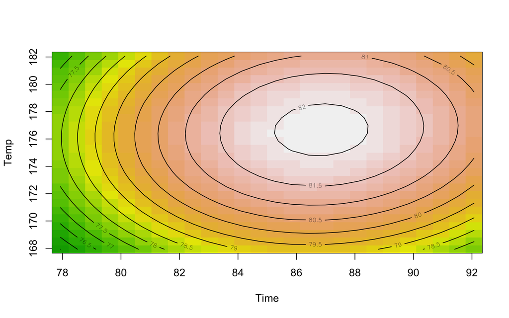

```r
contour(CR1.rsm, ~ Time + Temp, image = TRUE, at = summary(CR1.rsm)$canonical$xs)
```

To draw 3d plot, use `persp` function

[figure not shown]

```r
persp(CR1.rsm,
      Time ~ Temp, #plot xs
      col=rainbow(50),
      xlabs = c(expression("Time (min)", "Temperature (°C)")), # axis labels
      theta=30,
      phi=30, r = 120, d=120,
      border = NULL,
      ltheta = 0,
      lphi = 0,
              shade = 0.75, zlab="Yield", col.axis=37, font.lab=2, col.lab=35,
              contour=("colors"))
```

# Bibliography

[output not shown]